# Лабораторная работа №8

Имитационное моделирование

Ибрахим Мохсейн Алькамаль

1032225432@rudn.ru

Российский университет дружбы народов

2026-09-04

# Информация

## Докладчик

- Ибрахим Мохсейн Алькамаль
- Российский университет дружбы народов

# Цель работы

- Изучить принципы реализации эпидемиологических моделей в дискретно-событийном подходе.
- Реализовать и исследовать модели SIR и SEIR.
- Провести анализ чувствительности модели к изменению параметров.
- Исследовать влияние продолжительности заболевания, демографических процессов и вакцинации.
- Оценить производительность модели.
- Визуализировать результаты моделирования.

# Выполнение лабораторной работы

## Подготовка рабочего проекта

- Создан проект `lab08/project`.
- Скрипт `setup_project.jl` запущен в каталоге `lab08`.
- Сформировано проектное окружение Julia.
- Установлена зависимость `DrWatson`.

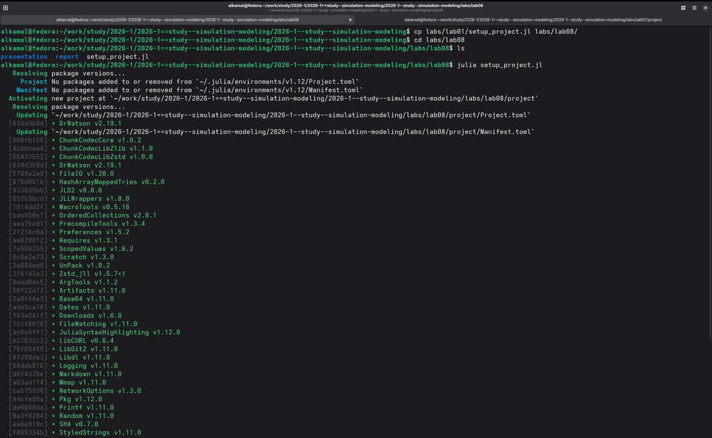

Рисунок 1: Создание рабочего проекта lab08 и инициализация окружения Julia

## Проверка проектного окружения

- Проект запущен командой `julia --project=.`.
- С помощью `Pkg.status()` проверены установленные пакеты.
- Проверено наличие пакетов для дискретно-событийного моделирования.

[figure not shown]

Рисунок 2: Проверка установленных пакетов проектного окружения Julia

## Выполнение дискретно-событийной модели SIR

- Подготовлены файлы `src/sir_model.jl` и `scripts/sir_des.jl`.
- Выполнен основной скрипт модели SIR.
- Построен график результатов моделирования.
- График сохранён в `plots/sir_des.png`.

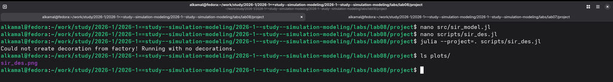

Рисунок 3: Выполнение дискретно-событийной модели SIR и сохранение графика

## Преобразование модели SIR в литературный стиль

- Подготовлен литературный файл `sir_des_literary.jl`.
- Файл обработан с помощью `tangle.jl`.
- Автоматически сформирован чистый Julia-скрипт.
- Сформированы документ Quarto и Jupyter Notebook.

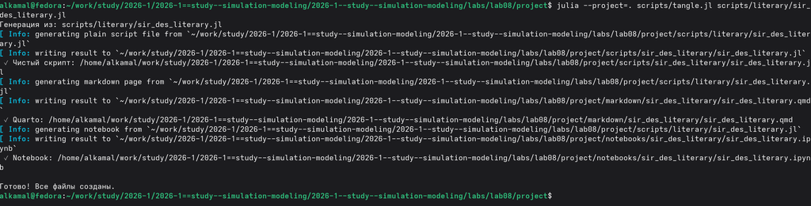

Рисунок 4: Генерация Julia-скрипта, документа Quarto и Jupyter Notebook для модели SIR

## Выполнение модели SIR в Jupyter Notebook

- Выполнен сгенерированный `sir_des_literary.ipynb`.
- Получена таблица значений `t`, `S`, `I`, `R`.
- Построен график изменения состояний модели во времени.
- Отображена динамика восприимчивых, инфицированных и выздоровевших.

[figure not shown]

Рисунок 5: Результаты дискретно-событийного моделирования SIR в Jupyter Notebook

## Исследование чувствительности модели к коэффициенту заражения

- Выполнен скрипт `sir_sensitivity.jl`.
- Исследовано влияние коэффициента заражения $\beta$.
- Проведены эксперименты для $\beta = 0.03$, $0.05$ и $0.07$.
- Определены максимальное число инфицированных и время достижения пика.
- Определено конечное число выздоровевших.
- Полученные графики сохранены в каталоге `plots`.

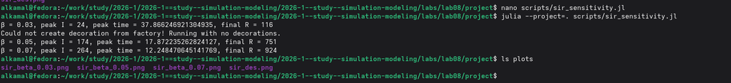

Рисунок 6: Выполнение анализа чувствительности SIR-модели к коэффициенту заражения β

## Преобразование анализа чувствительности в литературный стиль

- Подготовлен файл `sir_sensitivity_literary.jl`.
- Файл обработан с помощью `tangle.jl`.
- Автоматически сформирован чистый Julia-скрипт.
- Сформированы документ Quarto и Jupyter Notebook.

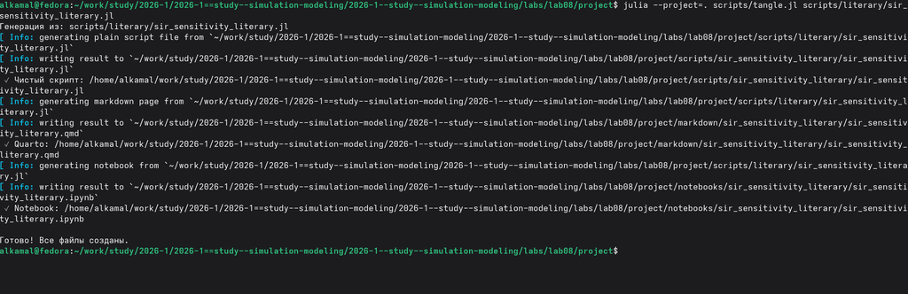

Рисунок 7: Генерация Julia-скрипта, документа Quarto и Jupyter Notebook для анализа чувствительности

## Выполнение анализа чувствительности в Jupyter Notebook

- Выполнен `sir_sensitivity_literary.ipynb`.
- Получены показатели `peak I`, `peak time` и `final R`.
- Результаты получены для трёх значений $\beta$.
- Сформированы графики `sir_beta_0.03.png`, `sir_beta_0.05.png` и `sir_beta_0.07.png`.

[figure not shown]

Рисунок 8: Результаты анализа чувствительности дискретно-событийной SIR-модели в Jupyter Notebook

## Сравнение случайной и фиксированной длительности болезни

- Создан файл `sir_model_fixed.jl` на основе базовой модели.
- Подготовлен скрипт `sir_compare_duration.jl`.
- Выполнено сравнение двух вариантов длительности болезни.
- Сформирован график `sir_duration_comparison.png`.
- График сохранён в каталоге `plots`.

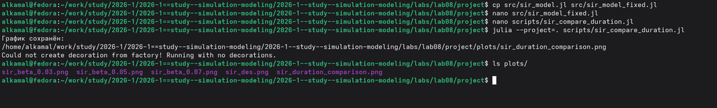

Рисунок 9: Выполнение сравнения моделей со случайной и фиксированной длительностью болезни

## Преобразование сравнения длительности болезни в литературный стиль

- Подготовлен файл `sir_compare_duration_literary.jl`.
- Файл обработан с помощью `tangle.jl`.
- Автоматически сформирован чистый Julia-скрипт.
- Сформированы документ Quarto и Jupyter Notebook.

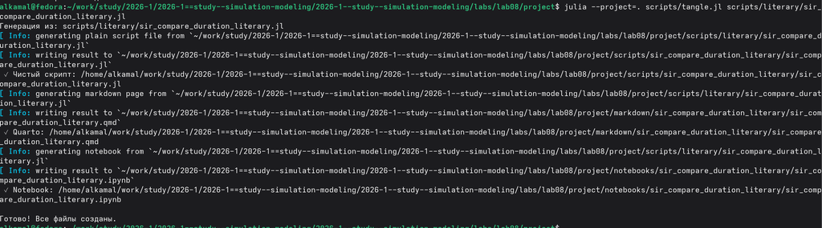

Рисунок 10: Генерация файлов литературной версии сравнения длительности болезни

## Анализ сравнения в Jupyter Notebook

- Выполнен `sir_compare_duration_literary.ipynb`.
- На одном графике представлены два варианта модели.
- Первый вариант использует случайную длительность болезни.
- Второй вариант использует фиксированную длительность инфекционного периода.
- Выполнено визуальное сравнение динамики числа инфицированных.

[figure not shown]

Рисунок 11: Сравнение динамики инфицированных при случайной и фиксированной длительности болезни

## Оценка производительности дискретно-событийной SIR-модели

- Выполнен скрипт `sir_benchmark.jl`.
- Тестирование проведено для `N = 10000`.
- Использован пакет `BenchmarkTools`.
- Оценены время выполнения, использование памяти и количество выделений.

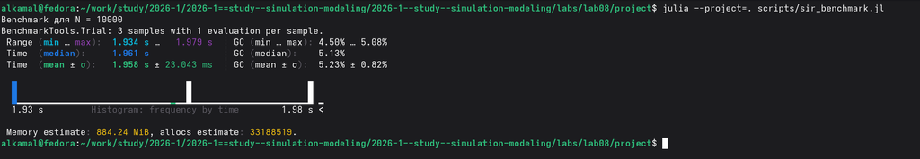

Рисунок 12: Результаты измерения производительности SIR-модели для популяции N = 10000

## Преобразование теста производительности в литературный стиль

- Подготовлен файл `sir_benchmark_literary.jl`.
- Выполнена обработка с помощью `tangle.jl`.
- Сформированы Julia-скрипт, документ Quarto и Jupyter Notebook.

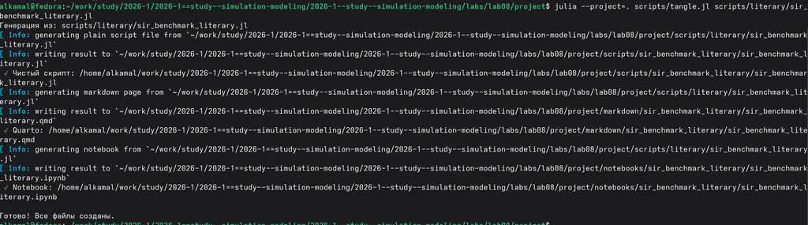

Рисунок 13: Генерация файлов литературной версии тестирования производительности SIR-модели

## Выполнение теста производительности в Jupyter Notebook

- Выполнен `sir_benchmark_literary.ipynb`.
- Тестирование проведено для `N = 10000`.
- Получены результаты `BenchmarkTools.Trial`.
- Представлены показатели времени, памяти и количества выделений.

[figure not shown]

Рисунок 14: Результаты тестирования производительности дискретно-событийной SIR-модели в Jupyter Notebook

## Сохранение результатов SIR-модели в формате CSV

- В скрипт `sir_des.jl` добавлено автоматическое сохранение результатов.
- CSV-файлы сохраняются в каталог `data/sims`.
- Имя файла формируется из начальных условий и параметров модели.

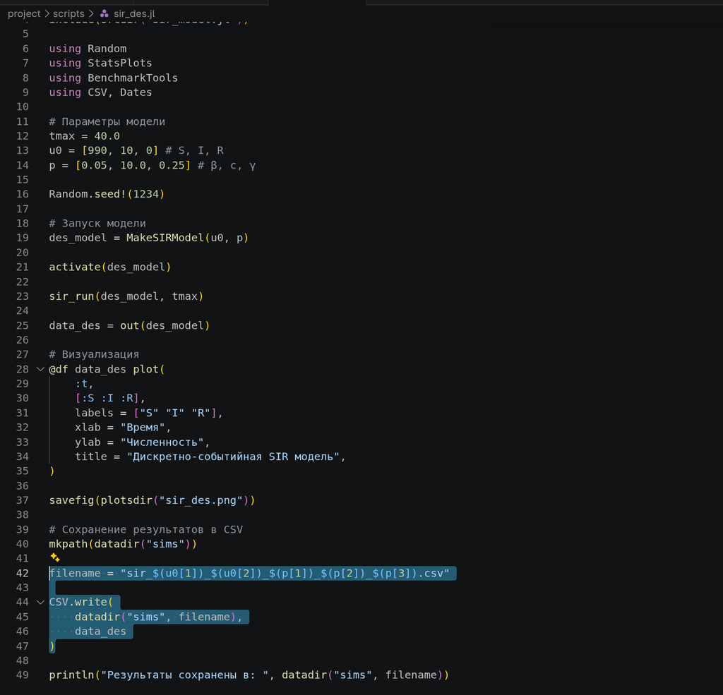

Рисунок 15: Реализация сохранения результатов дискретно-событийной SIR-модели в CSV

## Проверка сохранения результатов моделирования

- Создан файл `sir_990_10_0.05_10.0_0.25.csv`.
- Содержимое проверено командой `head`.
- Файл содержит столбцы `t`, `S`, `I` и `R`.

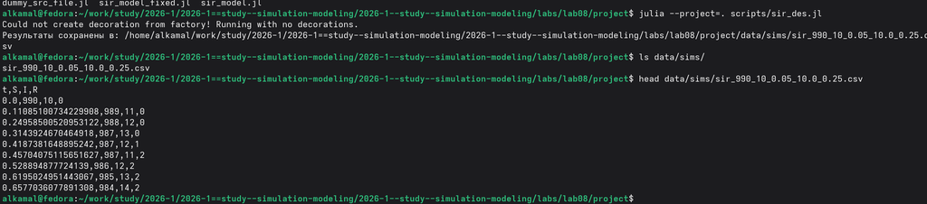

Рисунок 16: Проверка созданного CSV-файла с результатами SIR-модели

## Реализация SIR-модели с демографическими событиями

- Выполнен скрипт `sir_demography.jl`.
- Реализована модель с демографическими событиями.
- Получено `2531` наблюдение.
- Таблица содержит столбцы `t`, `S`, `I`, `R` и `D`.

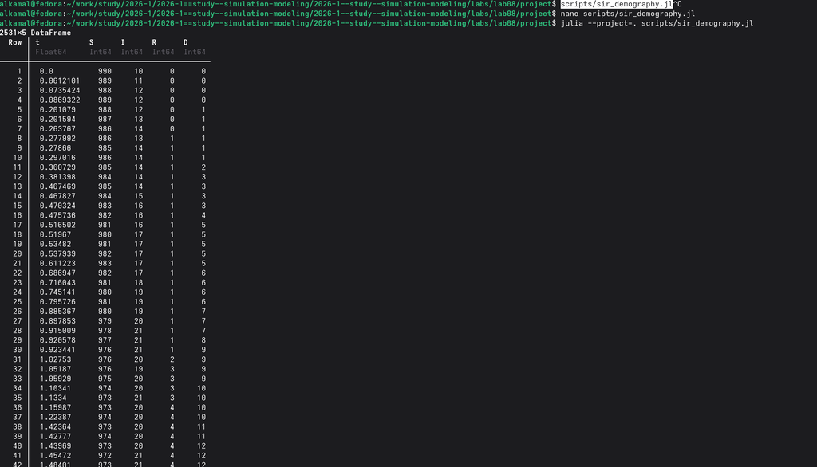

Рисунок 17: Результаты выполнения SIR-модели с демографическими событиями

## Сохранение результатов модели с демографическими событиями

- Результаты сохранены в CSV-файл в каталоге `data/sims`.
- График сохранён в `plots/sir_demography.png`.
- Наличие файлов проверено командами `ls`.

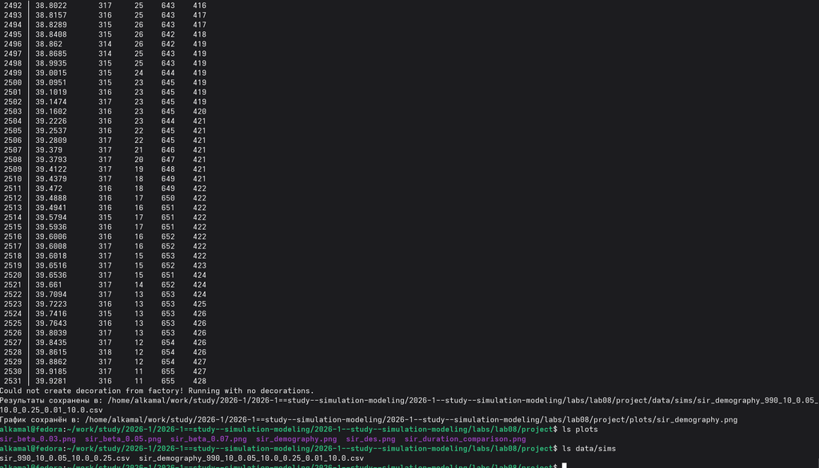

Рисунок 18: Сохранение результатов и графика SIR-модели с демографическими событиями

## Преобразование модели с демографическими событиями в литературный стиль

- Подготовлен файл `sir_demography_literary.jl`.
- Выполнена обработка с помощью `tangle.jl`.
- Сформированы Julia-скрипт, документ Quarto и Jupyter Notebook.

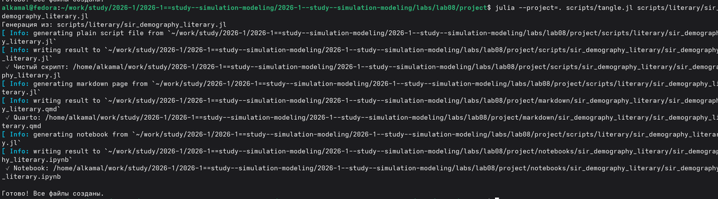

Рисунок 19: Генерация литературной версии SIR-модели с демографическими событиями

## Выполнение модели с демографическими событиями в Jupyter Notebook

- Выполнен `sir_demography_literary.ipynb`.
- Представлена таблица результатов.
- Построен график динамики `S`, `I`, `R` и `D`.

[figure not shown]

Рисунок 20: Результаты SIR-модели с демографическими событиями в Jupyter Notebook

## Реализация вакцинации в SIR-модели

- Созданы `sir_model_vaccination.jl` и `sir_vaccination.jl`.
- Вакцинация выполняется при `t = 10.0`.
- Вакцинируются `50 %` восприимчивых агентов.
- После моделирования выводятся основные показатели.
- Сохраняется график `sir_vaccination.png`.

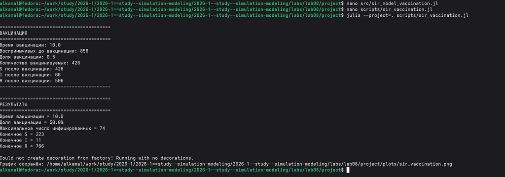

Рисунок 21: Выполнение дискретно-событийной SIR-модели с вакцинацией

## Преобразование модели вакцинации в литературный стиль

- Подготовлен файл `sir_vaccination_literary.jl`.
- Выполнена обработка с помощью `tangle.jl`.
- Сформированы Julia-скрипт, документ Quarto и Jupyter Notebook.

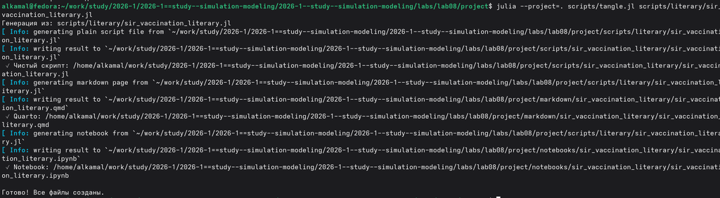

Рисунок 22: Генерация файлов литературной версии SIR-модели с вакцинацией

## Выполнение модели вакцинации в Jupyter Notebook

- Выполнен `sir_vaccination_literary.ipynb`.
- Построены графики динамики `S`, `I` и `R`.
- Момент вакцинации отмечен при `t = 10`.

[figure not shown]

Рисунок 23: Визуализация динамики SIR-модели и момента вакцинации в Jupyter Notebook

## Реализация SEIR-модели

- Создан файл `src/seir_model.jl`.
- В модель добавлено состояние `E` — латентная стадия заболевания.
- Подготовлен скрипт `scripts/seir_run.jl`.
- Начальное состояние: (S_0=990), (E_0=0), (I_0=10), (R_0=0).
- Средний латентный период — 2 единицы времени.
- Средняя продолжительность болезни — 4 единицы времени.
- Максимальное число инфицированных — 110.
- Пик достигнут при (t=31.296).
- Итоговая численность населения — 1000.

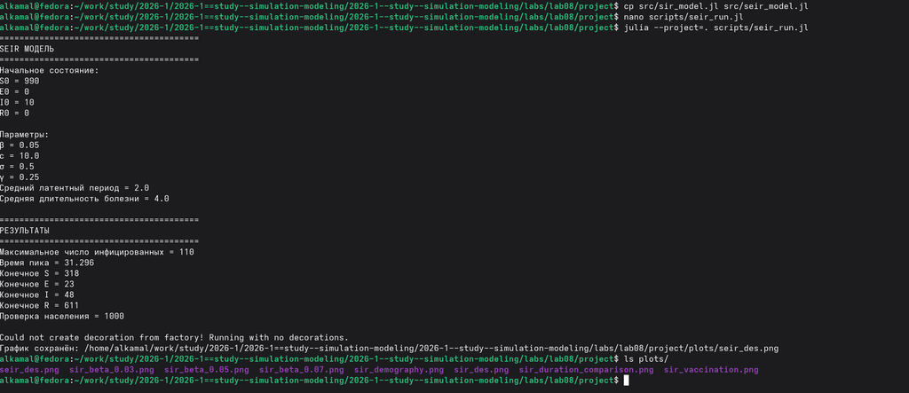

Рисунок 24: Запуск дискретно-событийной SEIR-модели и результаты моделирования